# Reproducible Research: Peer Assessment 1

## Loading and preprocessing the data

1. Load the data

```r
rm(list=ls())
data <- read.csv("activity.csv")
```

2. Process/transform the data (if necessary) into a format suitable for your analysis

```r
data$date <- as.Date(data$date)
```

## What is mean total number of steps taken per day?

1. Calculate the total number of steps taken per day (ignore the missing values in the dataset)

```r
library(dplyr)
by_date <- group_by(data,date)
data_by_date <- summarise(by_date, totalstep = sum(steps, na.rm=TRUE))
```

2. Make a histogram of the total number of steps taken each day

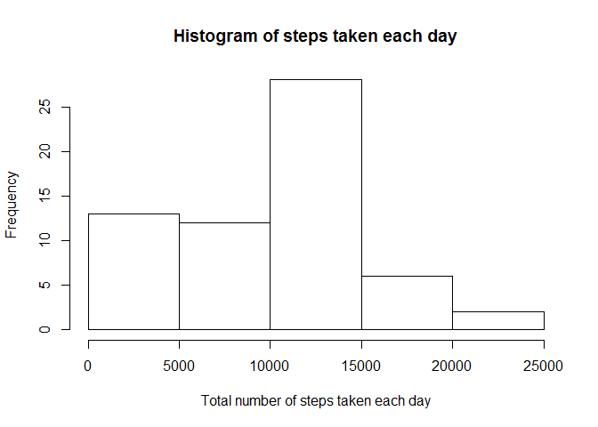

```r
hist(data_by_date$totalstep,
     xlab="Total number of steps taken each day",
     main = "Histogram of steps taken each day")
```

3. Calculate and report the mean and median of the total number of steps taken per day

```r
mean.steps <- mean(data_by_date$totalstep, na.rm=TRUE)
median.steps <- median(data_by_date$totalstep, na.rm=TRUE)
```

**So, the mean of the total number of steps taken per day is 9354.2295082, and the median of the total number of steps taken per day is 10395.**

## What is the average daily activity pattern?

1. Make a time series plot (i.e. type = “l”) of the 5-minute interval (x-axis) and the average number of steps taken, averaged across all days (y-axis)

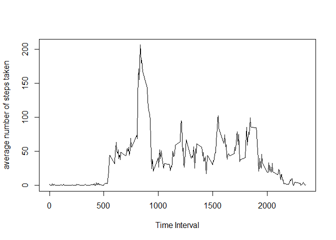

```r
by_interval <- group_by(data,interval)
data_by_interval <- summarise(by_interval, meanstep = mean(steps,na.rm=TRUE))

#data$interval <- sapply(data$interval,intToHHMM)
plot(data_by_interval, type="l",
     xlab="Time Interval", ylab="average number of steps taken")
```

2. Which 5-minute interval, on average across all the days in the dataset, contains the maximum number of steps?

```r
maxstep <- max(data_by_interval$meanstep, na.rm=TRUE)
maxstep_interval <- subset(data_by_interval, meanstep == maxstep)$interval
intToHHMM <- function (i) {  sprintf("%02d:%02d", i %/% 100, i %% 100)}
maxstep_interval_HHMM <- intToHHMM(maxstep_interval)
```

**So, the interval 835 (08:35) contains the maximum number of steps.**